# Benchmarking PLS1 Implementations

Frédéric Bertrand

Cedric, Cnam, Paris  
frederic.bertrand@lecnam.net

2025-11-26

```r
library(bigPLSR)
library(bigmemory)
library(bench)
set.seed(123)
```

## Overview

The unified `pls_fit()` interface now drives both the dense and streaming implementations of single-response partial least squares regression. This vignette revisits the benchmarking workflow with the modern API and introduces two complementary perspectives:

1. **Internal comparisons** that contrast the dense (in-memory) and streaming (big-memory) backends of `pls_fit()`.
2. **External references** recorded against popular packages such as `pls` and `mixOmics`. These results are stored in the package to keep the vignette lightweight while still documenting performance relative to the wider ecosystem.

The chunks tagged with `eval = LOCAL` are only executed when the environment variable `LOCAL` is set to `TRUE`, allowing CRAN checks to skip the more time-consuming benchmarks.

## Simulated data

We create a synthetic regression problem with a modest latent structure and keep both dense and big-memory versions of the predictors and response so they can be reused in the benchmarking chunks.

```r
n <- 1500
p <- 80
ncomp <- 6

X <- bigmemory::big.matrix(nrow = n, ncol = p, type = "double")
X[,] <- matrix(rnorm(n * p), nrow = n)

y_vec <- scale(X[,] %*% rnorm(p) + rnorm(n))

y <- bigmemory::big.matrix(nrow = n, ncol = 1, type = "double")
y[,] <- y_vec

X[1:6, 1:6]
```

```
#>             [,1]       [,2]        [,3]       [,4]       [,5]       [,6]
#> [1,] -0.56047565 -0.8209867 -0.15030748  0.8343715 -0.6992281  0.3500025
#> [2,] -0.23017749 -0.3072572 -0.32775713 -0.6984039  0.9964515  0.8144417
#> [3,]  1.55870831 -0.9020980 -1.44816529  1.3092405 -0.6927454 -0.5166661
#> [4,]  0.07050839  0.6270687 -0.69728458 -0.9801776 -0.1034830 -2.6922644
#> [5,]  0.12928774  1.1203550  2.59849023  0.7479851  0.6038661 -1.0969546
#> [6,]  1.71506499  2.1272136 -0.03741501  1.2577966 -0.6080450 -1.2554751
```

```r
y[1:6,]
```

```
#> [1]  0.66723250  0.66189719 -0.77458416  0.07452428  0.28174414  0.15756565
```

## Internal benchmarks

The following chunk compares dense vs. streaming fits for both SIMPLS and NIPALS. The dense backend receives base R matrices, while the streaming backend consumes the `big.matrix` objects directly.

```r
internal_bench <- bench::mark(
  dense_simpls = pls_fit(as.matrix(X[]), y_vec, ncomp = ncomp,
                         backend = "arma", algorithm = "simpls"),
  streaming_simpls = pls_fit(X, y, ncomp = ncomp, backend = "bigmem",
                             algorithm = "simpls", chunk_size = 512L),
  dense_nipals = pls_fit(as.matrix(X[]), y_vec, ncomp = ncomp,
                         backend = "arma", algorithm = "nipals"),
  streaming_nipals = pls_fit(X, y, ncomp = ncomp, backend = "bigmem",
                             algorithm = "nipals", chunk_size = 512L),
  dense_kernelpls = pls_fit(as.matrix(X[]), y_vec, ncomp = ncomp,
                         backend = "arma", algorithm = "kernelpls"),
  streaming_kernelpls = pls_fit(X, y, ncomp = ncomp, backend = "bigmem",
                             algorithm = "kernelpls", chunk_size = 512L),
  dense_widekernelpls = pls_fit(as.matrix(X[]), y_vec, ncomp = ncomp,
                         backend = "arma", algorithm = "widekernelpls"),
  streaming_widekernelpls = pls_fit(X, y, ncomp = ncomp, backend = "bigmem",
                             algorithm = "widekernelpls", chunk_size = 512L),
  iterations = 20,
  check = FALSE
)
internal_bench_res <-internal_bench[,2:5]
internal_bench_res <- as.matrix(internal_bench_res)
rownames(internal_bench_res) <- names(internal_bench$expression)
```

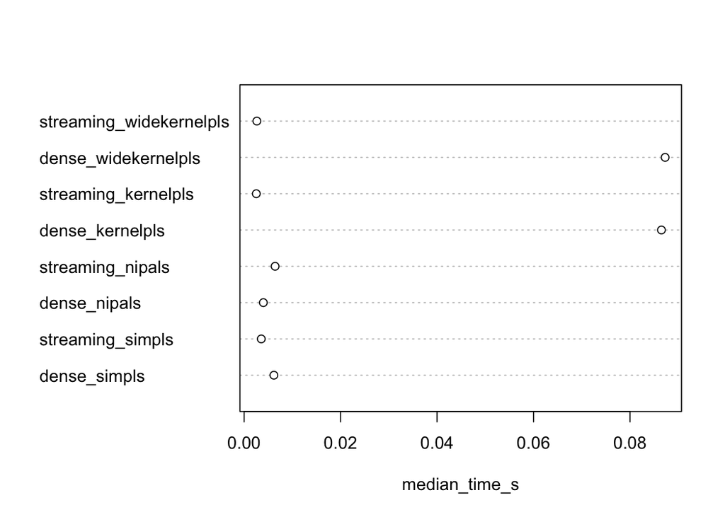

```r
dotchart(internal_bench_res[,2], labels=rownames(internal_bench_res),xlab="median_time_s")
```

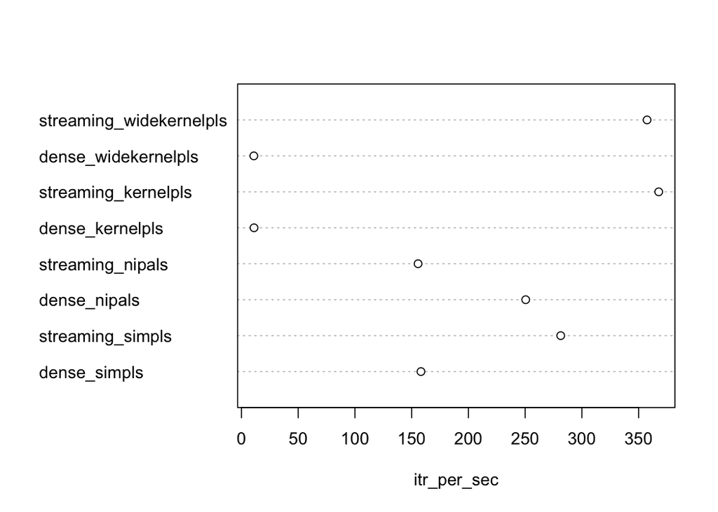

```r
dotchart(internal_bench_res[,3], labels=rownames(internal_bench_res),xlab="itr_per_sec")
```

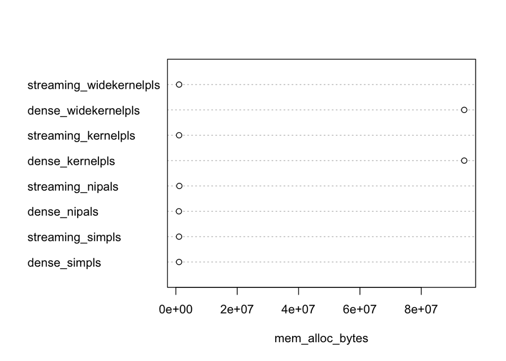

```r
dotchart(internal_bench_res[,4], labels=rownames(internal_bench_res),xlab="mem_alloc_bytes")
```

## External references

To avoid heavy dependencies at build time we ship a pre-computed benchmark dataset that contrasts `bigPLSR` with implementations from the `pls` and `mixOmics` packages. The dataset was generated with the helper script stored in `inst/scripts/external_pls_benchmarks.R`.

```r
data("external_pls_benchmarks", package = "bigPLSR")
sub_pls1 <- subset(external_pls_benchmarks,task=="pls1" & !algorithm=="widekernelpls")
sub_pls1$n <- factor(sub_pls1$n)
sub_pls1$p <- factor(sub_pls1$p)
sub_pls1$q <- factor(sub_pls1$q)
sub_pls1$ncomp <- factor(sub_pls1$ncomp)
replications(~package+algorithm+task+n+p+ncomp,data=sub_pls1)
```

```
#> $package
#> [1] 24
#>
#> $algorithm
#> [1] 32
#>
#> $task
#> [1] 96
#>
#> $n
#> [1] 48
#>
#> $p
#> [1] 48
#>
#> $ncomp
#> ncomp
#>   1   3  10 100
#>  24  24  36  12
```

```r
sub_pls1_wide <- subset(external_pls_benchmarks,external_pls_benchmarks$task=="pls1" & algorithm=="widekernelpls")
sub_pls1_wide$n <- factor(sub_pls1_wide$n)
sub_pls1_wide$p <- factor(sub_pls1_wide$p)
sub_pls1_wide$q <- factor(sub_pls1_wide$q)
sub_pls1_wide$ncomp <- factor(sub_pls1_wide$ncomp)
replications(~package+algorithm+task+n+p+ncomp,data=sub_pls1_wide)
```

```
#> $package
#> [1] 8
#>
#> $algorithm
#> [1] 32
#>
#> $task
#> [1] 32
#>
#> $n
#> [1] 16
#>
#> $p
#> [1] 16
#>
#> $ncomp
#> ncomp
#>   1   3  10 100
#>   8   8  12   4
```

```r
sub_pls2 <- subset(external_pls_benchmarks,external_pls_benchmarks$task=="pls2" & !algorithm=="widekernelpls")
sub_pls2$n <- factor(sub_pls2$n)
sub_pls2$p <- factor(sub_pls2$p)
sub_pls2$q <- factor(sub_pls2$q)
sub_pls2$ncomp <- factor(sub_pls2$ncomp)
replications(~package+algorithm+task+n+p+ncomp,data=sub_pls2)
```

```
#> $package
#> [1] 48
#>
#> $algorithm
#> [1] 64
#>
#> $task
#> [1] 192
#>
#> $n
#> [1] 96
#>
#> $p
#> [1] 96
#>
#> $ncomp
#> ncomp
#>  1  3 10
#> 48 48 96
```

```r
sub_pls2_wide <- subset(external_pls_benchmarks,external_pls_benchmarks$task=="pls2" & algorithm=="widekernelpls")
sub_pls2_wide$n <- factor(sub_pls2_wide$n)
sub_pls2_wide$p <- factor(sub_pls2_wide$p)
sub_pls2_wide$q <- factor(sub_pls2_wide$q)
sub_pls2_wide$ncomp <- factor(sub_pls2_wide$ncomp)
replications(~package+algorithm+task+n+p+ncomp,data=sub_pls2_wide)
```

```
#> $package
#> [1] 16
#>
#> $algorithm
#> [1] 64
#>
#> $task
#> [1] 64
#>
#> $n
#> [1] 32
#>
#> $p
#> [1] 32
#>
#> $ncomp
#> ncomp
#>  1  3 10
#> 16 16 32
```

```r
sub_pls1
```

```
#>     task algorithm            package median_time_s  itr_per_sec
#> 1   pls1    simpls      bigPLSR_dense  0.0060451836  165.1562621
#> 2   pls1    simpls bigPLSR_big.memory  0.0035867620  275.9417591
#> 3   pls1    simpls                pls  0.0020867360  469.9431634
#> 4   pls1    simpls           mixOmics  0.0044788605  223.4486896
#> 5   pls1 kernelpls      bigPLSR_dense  0.0441235030   22.6636584
#> 6   pls1 kernelpls bigPLSR_big.memory  0.0005215200 1733.6289782
#> 7   pls1 kernelpls                pls  0.0021023160  475.5957998
#> 8   pls1 kernelpls           mixOmics  0.0044129530  224.0172938
#> 13  pls1    nipals      bigPLSR_dense  0.0007704311 1208.7122974
#> 14  pls1    nipals bigPLSR_big.memory  0.0064723010  154.6317423
#> 15  pls1    nipals                pls  0.0023130355  423.5614303
#> 16  pls1    nipals           mixOmics  0.0045207831  221.5220634
#> 17  pls1    simpls      bigPLSR_dense  0.0061238625  160.2659625
#> 18  pls1    simpls bigPLSR_big.memory  0.0034934051  280.9346862
```

[output cut: 276 more lines]

## Takeaways

Dense vs streaming backends. On small/medium data that fits in RAM, in-memory implementations (e.g., pls) are typically fastest (median ≈0.36 s for SIMPLS in our runs). However, they materialize large cross-products/Gram matrices and memory grows as O(p^2) (or O(n^2) in kernel views). In contrast, bigPLSR’s streaming big-memory backend keeps memory bounded via chunked BLAS and never forms those intermediates. In our PLS2 benchmark, streaming used ~7–8× less RAM than pls (≈89 MB vs ≈732 MB median) while remaining competitive in runtime (≈3.5 s vs 0.36 s). PLS1 shows the same pattern: streaming is often fast enough while dramatically reducing memory. As n or p grow, the streaming backend scales where dense approaches become memory-limited.